# MUM 2023-24 Twierdzenie Bayesa

## Wzór Bayesa

$$p(\theta\mid x) = \dfrac{p(x\mid \theta)\cdot p(\theta)}{p(x)}$$

- Jeśli $\theta$ może przyjmować tylko skończenie wiele wartości, tzn. $\theta\in\{\theta^1, \ldots, \theta^T\}$, to możemy zapisać $$\begin{align} p(x) &= p(x, \theta = \Theta) = p(x, \theta=\Theta^1) + \ldots + p(x, \theta=\Theta^T)\\ &= p(x\mid\theta=\Theta^1)p(\theta=\Theta^1) + \ldots + p(x\mid\theta=\Theta^T)p(\theta=\Theta^T) \end{align}$$ i wstawić to do powyższego wzoru (po co? tak będzie wygodniej, o czym przekonamy się za chwilę):

$$\begin{align} p(\theta\mid x)&=\dfrac{p(x\mid \theta)\cdot p(\theta)}{p(x\mid\theta=\Theta^1)p(\theta=\Theta^1) + \ldots + p(x\mid\theta=\Theta^T)p(\theta=\Theta^T)}\\ &= \dfrac{p(x\mid \theta)\cdot p(\theta)}{\sum_{k}p(x\mid\theta=\Theta^k)p(\theta=\Theta^k)} \end{align}$$

- Sam wzór Bayesa wynika wprost z definicji, więc jest dość prosty. Znacznie ciekawsze będzie to, w jaki sposób go użyjemy.

### Wzór Bayesa pisany poprawnie

- Po dwóch stronach równości mamy dwie funkcje dwóch parametrów: $x$ oraz $\theta$.
  - Jeśli chcemy mieć równość liczb, a nie funkcji, to powinniśmy wybrać jakąś wartość $x$ - niech to będzie np. $x^1$ - oraz wartość $\theta$ - powiedzmy $\Theta^t$ dla pewnego $t\in\{1, \ldots, T\}$ - i napisać $$p(\theta = \theta^t\mid x = x^1) = \dfrac{p(x = x^1\mid\theta=\Theta^t)\cdot p(\theta=\Theta^t)}{p(x=x^1)}$$
  - Oczywiście równość zachodzi dla każdej pary dowolnie wybranych wartości $x$ oraz $\theta$.

### Wzór Bayesa - więcej zmiennych

- Zamiast $x$ i $\theta$ oczywiście możemy wstawić do wzoru Bayesa więcej zmiennych. Zasada jest podobna, np. $$p(\theta,\alpha\mid x,y,z) = \dfrac{p(x,y,z\mid \theta,\alpha)\cdot p(\theta,\alpha)}{p(x,y,z)}$$

## Uczenie maszynowe

- Przy założeniu **I.I.D.** wiedza o wartościach elementów ze zbioru treningowego nie ma prawa zmieniać naszej wiedzy na temat wartości ze zbioru testowego.
  - Czy to oznacza, że teoria jest niepoprawna, skoro modele się uczą?
- Teoria jest poprawna.
  - Powyższe stwierdzenie jest prawdziwe tylko wtedy, kiedy znamy rozkład $p(x)$.
  - Wtedy w oczywisty sposób samplowanie z tego rozkładu nie może zwiększać wiedzy na jego temat, ani też na temat przyszłych próbek
  - Natomiast dopóki nie znamy $p(x)$, samplowanie z tego rozkładu zwiększa naszą wiedzę na jego temat i w ten sposób, pośrednio, wiedzę o przyszłych samplach.
- Rozkład prawdopodobieństwa $p(x)$ mówi o niepewności konkretnej wartości wylosowanej z $x$.
  - jak formalnie zapisać naszą niepewność co do rozkładu $p$?
  - Czy to wymaga wprowadzenia nowej meta-teorii, która ma opisywać tę teorię?
  - Na szczęście nie.
- założenie IID nie zawsze jest spełnione
  - w niektórych typach uczenia (problemach) mamy do czynienia z rozkładami danych, które **zmieniają** się

### Parametr $\theta$

- Wprowadzamy rozkład łączny $p(x,\theta)$.
  - Musimy go zdefiniować sami, nie korzystając z żadnych danych treningowych.
  - Pomysł polega na tym, że różne ustalone wartości $\Theta$ oznaczają nasze różne hipotezy o **rozkładzie** $p(x)$.
  - Formalnie, np. hipoteza $\theta = \Theta^1$ oznacza **warunkowy** rozkład prawdopodobieństwa $$p(x\mid \theta=\Theta^1)$$

a nasz obecny stopień przekonania co do poprawności hipotezy $\theta = \Theta^1$ dany jest jako rozkład **brzegowy** $$p(\theta=\Theta^1)$$

- Nie "wybieramy" żadnej hipotezy, żeby powiedzieć coś o $x$ - używamy wszystkich hipotez jednocześnie, ważąc je prawdopodobieństwem $p(\theta)$.
- Nasza obecna wiedza o $x$ to po prostu drugi rozkład **brzegowy** $$p(x)$$

### Jak zdefiniować $p(x,\theta)$ bez danych treningowych

- musimy zadbać, żeby uwzględnić w tym rozkładzie wszystkie możliwe hipotezy.
  - jeśli modelujemy rzut niesymetryczną monetą, to $x$ może przyjąć jedną z dwóch wartości: orzeł lub reszka.
  - Natomiast $\theta$ musi przyjmować nieskończenie wiele wartości z przedziału $[0,1]$, jeśli zinterpretujemy $\theta=T$ jako "prawdopodobieństwo wypadnięcia orła wynosi $T$".
- Czyli np. definiujemy $p(x=\mathrm{orzeł}\mid\theta=T) = T$ oraz $p(x=\mathrm{reszka}\mid\theta=T) = 1-T$.
- Brakuje jeszcze $p(\theta)$ i tu pojawia się problem.
  - Nie ma żadnego "dobrego" rozkładu na $\theta$,
    - musimy po prostu wybrać cokolwiek.
  - Ten rozkład będzie się zmieniał podczas uczenia (o tym za chwilę)
    - w granicy nieskończenie wielu obserwacji wskaże nam "najprawdziwszą" hipotezę
    - jego wartość początkową trzeba "zgadnąć".
- Zły rozkład $p(\theta)$ może bardzo spowolnić uczenie
  - jeśli jesteśmy bardzo przekonani do niepoprawnej hipotezy, to musimy obejrzeć bardzo dużo przykładów, żeby w końcu zmienić zdanie.
- Wracając do pierwszego punktu
  - załóżmy, że w rozkładzie $p(x,\theta)$ **nie** uwzględnimy wszystkich możliwych hipotez,
    - nawet przy "nieskończenie wielu obserwacjach" możemy mieć niekompletną wiedzę o $x$.
  - niech początku pewne wartości $\theta$ będą miały prawdopodobieństwo zero
    - jeśli $p(\theta=T)=0$, to jesteśmy pewni, że $\theta\neq T$ i żadna liczba obserwacji $x$ nie przekona nas do $\theta=T$.

### Uczenie Bayesowskie — znowu założenie I.I.D.

- Założenie I.I.D. obowiązuje tylko przy ustalonej hipotezie, to znaczy przy ustalonej wartości $\theta$.
  - Czyli dla dowolnej wartości $\Theta^k$ $$p(x_1=x^1, \ldots, x_N=x^N\mid\theta=\Theta^k) = p(x=x^1\mid\theta=\Theta^k)\ldots p(x=x^N\mid\theta=\Theta^k)$$
  - Chcemy w ten sposób powiedzieć: "nie wiemy, która hipoteza najlepiej opisuje $x$, ale każda z tych hipotez spełnia wg nas założenie I.I.D.".
  - Kluczowe jest to, że teraz $$p(x_1=x^1, \ldots, x_N=x^N) \neq p(x=x^1)\ldots p(x=x^N)$$ czyli być może uda się wnioskować o kolejnych samplach na podstawie poprzednich.
- Niech $D_{Tr}$ oznacza nasz zbiór treningowy ($D$ jak *dataset*) o rozmiarze $N$. $$D_{Tr}=\{x_1=x^1, x_2=x^2 \ldots, x_N=x^N\}$$
- Chcemy teraz wnioskować o $x_{N+1}$ na podstawie $D_{Tr}$.
  - Załóżmy na chwilę, że $\theta$ może przyjmować tylko skończenie wiele wartości ze zbioru $\{\Theta^1, \ldots, \Theta^K\}$.
  - To bardzo niepoprawne założenie, ale dzięki temu zobaczymy wzór ze skończoną sumą.
  - W ogólnym przypadku, jeśli mamy szczęście, zamiast sumy jest bardzo skomplikowana całka.

### Posterior Predictive Distribution (PPD)

$$\begin{align} p(x_{N+1}\mid D_{Tr}) &= p(x_{N+1}\mid\theta=\Theta^1)p(\theta=\Theta^1\mid D_{Tr}) + \ldots + p(x_{N+1}\mid\theta=\Theta^K)p(\theta=\Theta^K\mid D_{Tr})\\ &= \sum_{k=1}^K p(x_{N+1}\mid\theta=\Theta^k)p(\theta=\Theta^k\mid D_{Tr}) \end{align}$$

- Rozbijamy $\theta$ na wszystkie możliwe przypadki.
  - Wiedza o $x_{N+1}$ to średnia wiedza po wszystkich możliwych hipotezach. Ale używamy tu "zmienionego" rozkładu brzegowego $p(\theta)$, ponieważ warunkujemy go zbiorem treningowym!
  - Jak policzyć $p(\theta=\theta^k\mid D_{Tr})$? Użyjmy wzoru Bayesa. $$p(\theta=\Theta^k\mid D_{Tr}) = \dfrac{p(D_{Tr}\mid\theta=\Theta^k)p(\theta=\Theta^k)}{p(D_{Tr})}$$

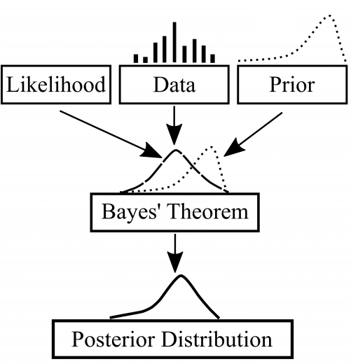

- Zamieniliśmy jedno $p$ na trzy różne — czy to pomogło?
  - Przypomnijmy, że mamy zdefiniowany rozkład $p(x,\theta)$.
  - W praktyce możemy założyć, że łatwo policzyć $p(\theta)$ oraz $p(x\mid\theta)$ dla dowolnej wartości $\Theta$
    - z reguły tak się właśnie definiuje ten rozkład łączny — poprzez każdą hipotezę z osobna oraz rozkład na hipotezach).
  - Pokażmy, jak policzyć wyrazy występujące w ułamku:
  1. $p(D_{Tr}\mid\theta=\Theta^k)$ to prawdopodobieństwo zbioru treningowego w hipotezie $\theta=\Theta^k$: $$p(D_{Tr}\mid\theta=\Theta^k) = p(x=x^1\mid\theta=\Theta^k)\ldots p(x=x^N\mid\theta=\Theta^k)$$
  - uwaga — tu korzystamy z założenia I.I.D.)
  2. $p(\theta=\Theta^k)$ odczytujemy po prostu z rozkładu brzegowego $p(\theta)$
  3. $p(D_{Tr})$ trzeba rozpisać (właśnie dlatego na początku tego notebooka wzór Bayesa rozpisywaliśmy mianownik): $$p(D_{Tr}) = p(D_{Tr}\mid\theta=\Theta^1)p(\theta=\Theta^1) + \ldots + p(D_{Tr}\mid\theta=\Theta^K)p(\theta=\Theta^K)$$ ale to już umiemy policzyć, patrz punkty 1. i 2.
- To jest pełna odpowiedź na pytanie: *zbiór treningowy nie daje nam żadnej nowej wiedzy na temat punktów ze zbioru testowego. Ale przecież to stoi w sprzeczności z faktem, że modele się uczą. Jak to wytłumaczyć?*
  - Zaobserwowany zbiór treningowy niejako zmienia rozkład brzegowy $p(\theta)$
  - tak naprawdę ten rozkład nie może się zmienić, ale wzory *wyglądają* tak, jak gdyby został on uwarunkowany zbiorem treningowym
  - ten "zmieniony" rozkład służy do ważonego uśrednienia wszystkich hipotez o $x_{N+1}$.
- Zamiast $x_{N+1}$ możemy wstawić dowolnie wiele kolejnych losowań, np. cały zbiór testowy.
- **posterior predictive distribution** to prawdopodobny rozkład wszystkich niezaobserwowanych wartości uwarunkowany wartościami obserwowanymi

### Prior, likelihood, posterior

$$p(\theta=\Theta^k\mid D_{Tr}) = \dfrac{p(D_{Tr}\mid \theta=\Theta^k)\cdot p(\theta=\Theta^k)}{\sum_{k}p(D_{Tr}\mid\theta=\Theta^k)p(\theta=\Theta^k)}$$

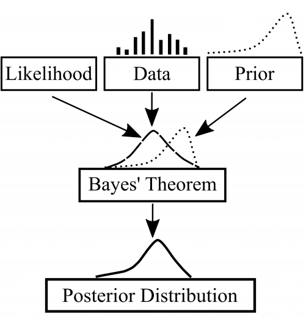

- $p(\theta=\Theta^k)$ w liczniku wzoru Bayesa to **prior** albo **wiedza a priori**, czyli wszystko to, co wiemy o wartościach $\theta$ bez patrzenia na zbiór treningowy $D_{Tr}$,
- $p(D_{Tr}\mid\theta=\Theta^k)$ w liczniku to **likelihood**, który mówi nam, jak bardzo prawdopodobny byłby dataset $D_{Tr}$, gdyby $\Theta^k$ było prawdziwą hipotezą,
- $p(\theta=\Theta^k\mid D_{Tr})$ po lewej stronie równości to **posterior** albo **wiedza a posteriori**, czyli wszystko to, co wiemy o wartościach $\theta$ po obejrzeniu zbioru treningowego $D_{Tr}$.
- $\sum_{k}p(D_{Tr}\mid\theta=\Theta^k)p(\theta=\Theta^k)$ to **evidence**

## Teoria a praktyka

$$p(x_{N+1}\mid D_{Tr}) = \sum_{k=1}^K p(x_{N+1}\mid\theta=\Theta^k)p(\theta=\Theta^k\mid D_{Tr})$$ opisuje wszystko, czego możemy się nauczyć. Nie da się wyciągnąć z $D_{Tr}$ jeszcze więcej wiedzy o $x_{N+1}$.

- Ale
  - Nie da się uwzględnić wszystkich hipotez w $p(x,\theta)$.
    - Już w wypadku rzutu monetą obliczenia są skomplikowane, a to przecież jest najprostszy z możliwych przykładów i daleko mu do problemów, które stawiamy przed sieciami neuronowymi.
  - Nie da się sensownie przeliczyć PPD, może za wyjątkiem bardzo specyficznych rozkładów $p(\theta,x)$.
- Machine Learning to sztuka znalezienia dobrego i szybkiego przybliżenia powyższego wzoru.
  - Poniżej dwa najpopularniejsze podejścia.
  - Niestety, oba zakładają "wybór" jednej z hipotez.

### Maximum a Posteriori (MAP)

- Szukamy takiego $\widehat\theta$, które zmaksymalizuje wartość liczbową posteriora: $$\widehat\theta = \operatorname{arg}\max_{\theta^k} p(\theta=\Theta^k\mid D_{Tr})$$
  - a następnie "wybieramy" to jedno $\widehat\theta$ i tylko na jego podstawie dokonujemy predykcji: $$p(x_{N+1}\mid D_{Tr}) \cong p(x_{N+1}\mid\theta=\widehat\Theta)$$
  - innymi słowy liczymy na to, że: $$p(\theta=\widehat\theta\mid D_{Tr})\simeq1$$ i wtedy $$\sum_{k=1}^K p(x_{N+1}\mid\theta=\Theta^k)p(\theta=\Theta^k\mid D_{Tr}) \cong p(x_{N+1}\mid\theta=\widehat\Theta)$$

### Maximum Likelihood Estimator (MLE)

Szukamy takiego $\theta^k$, które zmaksymalizuje wartość liczbową likelihoodu:

$$\widehat\theta = \underset{\Theta^k}{\arg\max}\;p\,(D_{Tr}\mid\theta=\Theta^k)$$

### Overfitting,

- sytuacja, w której model zapamiętuje zbiór treningowy, ale nie umie potem wykorzystać tej wiedzy do predykcji na zbiorze testowym.
  - to cena, jaką płacimy za zastąpienie PPD przez MLE.
  - overfitting **nie występuje** w przypadku PPD - to jest wzór dokładny, więc nic się nie może "zepsuć".
  - to zjawisko charakterystyczne właśnie dla MLE.